# GDAC_Capstone_Cyclistic

Kenny Chiang Kai Kuang

9/9/2021

## Case Study: How does a bike-share navigate speedy success?

### Background

**Cyclistic** is a bike-share program that features more than 5,800 bicycles and 600 docking stations. Cyclistic users are more likely to ride for leisure, but about 30% use them to commute to work each day. Cyclistic offers 3 pricing plans: single-ride passes, full-day passes, and annual memberships. Customers who purchase single-ride or full-day passes are referred to as **casual** riders, while customers who purchase annual memberships are Cyclistic **members**.

Cyclistic’s finance analysts have concluded that annual members are much more profitable than casual riders. The Director or Marketing (Lily Moreno) believes that maximizing the number of annual members will be key to future growth.

**Goal:** Design marketing strategies aimed at converting casual riders into annual members. In order to do that, the analytical objectives below must be met:

**Analytical Objectives:**

1. How do annual members and casual riders use Cyclistic bikes differently?
2. Why would casual riders buy Cyclistic annual memberships?
3. How can Cyclistic use digital media to influence casual riders to become members?

**Data Source(s):**

As per the case study guidelines, we will be using the publicly available dataset from Divvy, a bike-share company based in Chicago. The data is made available by Motivate International Inc. under this [license](https://www.divvybikes.com/data-license-agreement).

### Importing Libraries

```r
library(tidyverse) #helps wrangle data
library(dplyr) #helps manipulate data
library(lubridate) #helps wrangle date attributes
library(ggplot2) #helps visualize data
library(gdata) #for the duplicated2 function
library(janitor)
library(here)
```

### Importing data

```r
d08_2021 <- read_csv(here("data","202108-divvy-tripdata.csv"))
d07_2021 <- read_csv(here("data","202107-divvy-tripdata.csv"))
d06_2021 <- read_csv(here("data","202106-divvy-tripdata.csv"))
d05_2021 <- read_csv(here("data","202105-divvy-tripdata.csv"))
d04_2021 <- read_csv(here("data","202104-divvy-tripdata.csv"))
d03_2021 <- read_csv(here("data","202103-divvy-tripdata.csv"))
d02_2021 <- read_csv(here("data","202102-divvy-tripdata.csv"))
d01_2021 <- read_csv(here("data","202101-divvy-tripdata.csv"))
d12_2020 <- read_csv(here("data","202012-divvy-tripdata.csv"))
d11_2020 <- read_csv(here("data","202011-divvy-tripdata.csv"))
d10_2020 <- read_csv(here("data","202010-divvy-tripdata.csv"))
d09_2020 <- read_csv(here("data","202009-divvy-tripdata.csv"))
```

### Data Cleaning & Preparation

```r
#comparing column names and data types
compare_df_cols(d08_2021,d07_2021,d06_2021,d05_2021,d04_2021,d03_2021,
                d02_2021,d01_2021,d12_2020,d11_2020,d10_2020,d09_2020)
```

```
##           column_name        d08_2021        d07_2021        d06_2021
## 1             end_lat         numeric         numeric         numeric
## 2             end_lng         numeric         numeric         numeric
## 3      end_station_id       character       character       character
## 4    end_station_name       character       character       character
## 5            ended_at POSIXct, POSIXt POSIXct, POSIXt POSIXct, POSIXt
## 6       member_casual       character       character       character
## 7             ride_id       character       character       character
## 8       rideable_type       character       character       character
## 9           start_lat         numeric         numeric         numeric
## 10          start_lng         numeric         numeric         numeric
## 11   start_station_id       character       character       character
## 12 start_station_name       character       character       character
## 13         started_at POSIXct, POSIXt POSIXct, POSIXt POSIXct, POSIXt
##           d05_2021        d04_2021        d03_2021        d02_2021
```

[output cut: 41 more lines]

As observed from the output above, we need to **convert the datatype for ‘end_station_id’ and ‘start_station_id’ for `d11_2020, d10_2020 and d09_2020’ from numeric to character** so that they can stack properly in a combined dataframe.

```r
#convert datatype to character to build a single dataframe
d09_2020 <- mutate(d09_2020,
                   start_station_id = as.character(start_station_id),
                   end_station_id = as.character(end_station_id))
d10_2020 <- mutate(d10_2020,
                   start_station_id = as.character(start_station_id),
                   end_station_id = as.character(end_station_id))
d11_2020 <- mutate(d11_2020,
                   start_station_id = as.character(start_station_id),
                   end_station_id = as.character(end_station_id))
```

As the column names and datatypes are now consistent across the dataset for the last 12-months, we can proceed to combine the data into a single dataframe for further analysis.

```r
#combining the data for the last 12 months into one dataframe
df <- bind_rows(d08_2021,d07_2021,d06_2021,d05_2021,d04_2021,d03_2021,
                d02_2021,d01_2021,d12_2020,d11_2020,d10_2020,d09_2020)
```

Taking a preview of the data:

```r
head(df)
```

```
## # A tibble: 6 x 13
##   ride_id          rideable_type started_at          ended_at            start_station_n~
##   <chr>            <chr>         <dttm>              <dttm>              <chr>
## 1 99103BB87CC6C1BB electric_bike 2021-08-10 17:15:49 2021-08-10 17:22:44 <NA>
## 2 EAFCCCFB0A3FC5A1 electric_bike 2021-08-10 17:23:14 2021-08-10 17:39:24 <NA>
## 3 9EF4F46C57AD234D electric_bike 2021-08-21 02:34:23 2021-08-21 02:50:36 <NA>
## 4 5834D3208BFAF1DA electric_bike 2021-08-21 06:52:55 2021-08-21 07:08:13 <NA>
## 5 CD825CB87ED1D096 electric_bike 2021-08-19 11:55:29 2021-08-19 12:04:11 <NA>
## 6 612F12C94A964F3E electric_bike 2021-08-19 12:41:12 2021-08-19 12:47:47 <NA>
## # ... with 8 more variables: start_station_id <chr>, end_station_name <chr>,
## #   end_station_id <chr>, start_lat <dbl>, start_lng <dbl>, end_lat <dbl>,
## #   end_lng <dbl>, member_casual <chr>
```

```r
glimpse(df)
```

```
## Rows: 4,913,072
## Columns: 13
## $ ride_id            <chr> "99103BB87CC6C1BB", "EAFCCCFB0A3FC5A1", "9EF4F46C57~
## $ rideable_type      <chr> "electric_bike", "electric_bike", "electric_bike", ~
## $ started_at         <dttm> 2021-08-10 17:15:49, 2021-08-10 17:23:14, 2021-08-~
## $ ended_at           <dttm> 2021-08-10 17:22:44, 2021-08-10 17:39:24, 2021-08-~
## $ start_station_name <chr> NA, NA, NA, NA, NA, NA, NA, NA, NA, NA, NA, NA, NA,~
## $ start_station_id   <chr> NA, NA, NA, NA, NA, NA, NA, NA, NA, NA, NA, NA, NA,~
## $ end_station_name   <chr> NA, NA, NA, NA, NA, NA, NA, "Clark St & Grace St", ~
## $ end_station_id     <chr> NA, NA, NA, NA, NA, NA, NA, "TA1307000127", NA, NA,~
## $ start_lat          <dbl> 41.77000, 41.77000, 41.95000, 41.97000, 41.79000, 4~
## $ start_lng          <dbl> -87.68000, -87.68000, -87.65000, -87.67000, -87.600~
## $ end_lat            <dbl> 41.77000, 41.77000, 41.97000, 41.95000, 41.77000, 4~
## $ end_lng            <dbl> -87.68000, -87.63000, -87.66000, -87.65000, -87.620~
## $ member_casual      <chr> "member", "member", "member", "member", "member", "~
```

The combined dataset has **4,913,072 rows and 13 columns**.

#### Check for duplicates

```r
sum(duplicated(df))
```

[output not shown]

**No duplicate entries were found** in the combined dataframe. In the event there were duplicates, we can redefine “df” with the code below to remove any duplicates:

```r
df <- df[!duplicated(df), ]
```

#### Check for missing values

```r
sum(is.na(df))
```

```
## [1] 1893790
```

To further investigate where these missing values are present, we run the code below:

```r
#percent missing values per variable
apply(df, 2, function(col)sum(is.na(col))/length(col))
```

```
##            ride_id      rideable_type         started_at           ended_at
##        0.000000000        0.000000000        0.000000000        0.000000000
## start_station_name   start_station_id   end_station_name     end_station_id
##        0.091601548        0.091708609        0.100014818        0.100092976
##          start_lat          start_lng            end_lat            end_lng
##        0.000000000        0.000000000        0.001020746        0.001020746
##      member_casual
##        0.000000000
```

We observe that there are **missing values** in **‘start_station_name’, ‘start_station_id’, ‘end_station_name’, ‘end_station_id’, ‘end_lat’ and ‘end_lng’**.

We will attempt to fill the missing values in **‘start_station_name’ and ‘end_station_name’** - we can ignore the rest as we will drop them from the dataframe and not be used for analysis.

#### Investigating missing values in ‘start_station_name’ and ‘end_station_name’

Given that there are no latitude/longitude values missing for the starting point, we should be able to fill the missing values for ‘start_station_name’. However, there are missing latitude/longitude values for the ending point which might cause issues when trying to fill. We will observe the impact later.

To start, we first create a latitude/longitude column in the dataframe to get unique combinations to ‘start_station_name’ with their respective latitude/longitude and the same for ‘end_station_name’:

```r
df$start_latlng <- paste(df$start_lat, df$start_lng, sep = "/")
df$end_latlng <- paste(df$end_lat, df$end_lng, sep = "/")
```

We get the unique combinations for ‘start_station_name’ below:

```r
#for starting point
unique_start <- unique(df[c("start_station_name", "start_latlng")])
#drop missing values
unique_start <- unique_start[!is.na(unique_start$start_station_name),]

#for ending point
unique_end <- unique(df[c("end_station_name", "end_latlng")])
#drop missing values
unique_end <- unique_end[!is.na(unique_end$end_station_name),]
```

Next, we will proceed to fill-in the missing values from the unique combinations:

```r
#for starting point
#find the index of missing start_station_name in dataframe
missing_ssn <- which(is.na(df$start_station_name))
corresponding_slatlng <- df$start_latlng[missing_ssn]

#replace the missing start_station_name with unique combination
df$start_station_name[missing_ssn] <- unique_start$start_station_name[match(corresponding_slatlng, unique_start$start_latlng)]

#for ending point
#find the index of missing end_station_name in dataframe
missing_esn <- which(is.na(df$end_station_name))
corresponding_elatlng <- df$end_latlng[missing_esn]

#replace the missing start_station_name with unique combination
df$end_station_name[missing_esn] <- unique_end$end_station_name[match(corresponding_elatlng, unique_end$end_latlng)]
```

We re-run the code below to observe the missing values % in each column:

```r
#percent missing values per variable
apply(df, 2, function(col)sum(is.na(col))/length(col))
```

```
##            ride_id      rideable_type         started_at           ended_at
##        0.000000000        0.000000000        0.000000000        0.000000000
## start_station_name   start_station_id   end_station_name     end_station_id
##        0.080290091        0.091708609        0.087622164        0.100092976
##          start_lat          start_lng            end_lat            end_lng
##        0.000000000        0.000000000        0.001020746        0.001020746
##      member_casual       start_latlng         end_latlng
##        0.000000000        0.000000000        0.000000000
```

Using this method, we **managed to fill ~ 1% of the missing values in both start_station_name and end_station_name**. We also checked whether there were instances where start_ or end_station_id is present but start_ or end_station_name is missing - there are 0 instances.

Another method explored was downloading the most current list of stations (source below) and cross-checking with our dataframe to attempt to fill the missing values:

Source: https://data.cityofchicago.org/Transportation/Divvy-Bicycle-Stations-All-Map/bk89-9dk7

```r
stations <- read_csv(here("data","Divvy_Bicycle_Stations.csv"))
```

A preview of the list of stations imported:

```r
head(stations)
```

```
## # A tibble: 6 x 8
##      ID `Station Name`  `Total Docks` `Docks in Servi~ Status Latitude Longitude
##   <dbl> <chr>                   <dbl>            <dbl> <chr>     <dbl>     <dbl>
## 1   373 Kedzie Ave & C~            11               11 In Se~     41.9     -87.7
## 2   107 Desplaines St ~            27               27 In Se~     41.9     -87.6
## 3   102 Stony Island A~            11               11 In Se~     41.8     -87.6
## 4   438 Central Park A~            15               15 In Se~     41.9     -87.7
## 5   656 Damen Ave & Wa~            15               15 In Se~     41.9     -87.7
## 6   560 Marshfield Ave~            11               11 In Se~     41.8     -87.7
## # ... with 1 more variable: Location <chr>
```

```r
#create lat/lng column with similar format to match
#we round to 2 d.p. to match our dataframe's precision
stations$latlng <- paste(
  formatC(stations$Latitude, digits = 2, format = "f"),
  formatC(stations$Longitude, digits = 2, format = "f"),
  sep = "/")

#for starting point
#find the index of missing start_station_name in dataframe
missing_ssn <- which(is.na(df$start_station_name))
corresponding_slatlng <- df$start_latlng[missing_ssn]

#replace the missing start_station_name with external database of names
df$start_station_name[missing_ssn] <- stations$"Station Name"[match(corresponding_slatlng, stations$latlng)]

#for ending point
#find the index of missing end_station_name in dataframe
missing_esn <- which(is.na(df$end_station_name))
corresponding_elatlng <- df$end_latlng[missing_esn]

#replace the missing start_station_name with external database of names
df$end_station_name[missing_esn] <- stations$"Station Name"[match(corresponding_elatlng, stations$latlng)]
```

We re-run the missing values % check again:

```r
#percent missing values per variable
apply(df, 2, function(col)sum(is.na(col))/length(col))
```

```
##            ride_id      rideable_type         started_at           ended_at
##        0.000000000        0.000000000        0.000000000        0.000000000
## start_station_name   start_station_id   end_station_name     end_station_id
##        0.029472192        0.091708609        0.032232176        0.100092976
##          start_lat          start_lng            end_lat            end_lng
##        0.000000000        0.000000000        0.001020746        0.001020746
##      member_casual       start_latlng         end_latlng
##        0.000000000        0.000000000        0.000000000
```

We **further reduced the missing values in start_ and end_station_name to 3% for both** - this is an acceptable range to consider dropping the missing values. However, since the objective is not towards machine learning application, we will keep the 3% of data as the other columns provide useful information.

#### Dropping not useful columns from the dataframe

As we will not be using the lattitude and longitude data, we will drop it from the dataframe. We also drop ‘start_station_id’ and ‘end_station_id’ as we will be looking at station names instead. Lastly, we will also drop ‘ride_id’ as it is a unique identifier as we will group the data by time (days, months, years).

We will also drop the dataframe: “stations” as we will no longer require it and dropping it will help free up memory.

```r
df = select(df, -c(start_lat, start_lng, end_lat, end_lng, start_latlng, end_latlng, start_station_id, end_station_id, ride_id))

#dropping station dataframe
remove(stations)
```

### Feature Engineering

#### Creating columns for month, day and year

```r
df$date <- as.Date(df$started_at)
df$year <- format(as.Date(df$date), "%Y")
df$month <- format(as.Date(df$date), "%m")
df$day <- format(as.Date(df$date), "%d")
df$day_of_week <- format(as.Date(df$date), "%A")
#to set the order for 'day_of_week'
df$day_of_week <- ordered(df$day_of_week,
                          levels = c("Monday", "Tuesday", "Wednesday",
                                     "Thursday", "Friday", "Saturday",
                                     "Sunday"))
```

#### Creating column for ride_length

```r
df$ride_length_secs <- difftime(df$ended_at, df$started_at)
df$ride_length_secs <- as.numeric(df$ride_length_secs) #we cast 'ride_length' to numeric for calculations
df$ride_length_days <- round(df$ride_length_secs / 86400, 2)
df$ride_length_mins <- round(df$ride_length_secs / 60, 2)
df$ride_length_hours <- round(df$ride_length_secs / 3600, 2)
```

### Exploratory Data Analysis (EDA)

We begin the EDA process by taking a glimpse at the dataframe with new features. We want to ensure that they are in the correct datatype.

```r
glimpse(df)
```

```
## Rows: 4,913,072
## Columns: 15
## $ rideable_type      <chr> "electric_bike", "electric_bike", "electric_bike", ~
## $ started_at         <dttm> 2021-08-10 17:15:49, 2021-08-10 17:23:14, 2021-08-~
## $ ended_at           <dttm> 2021-08-10 17:22:44, 2021-08-10 17:39:24, 2021-08-~
## $ start_station_name <chr> NA, NA, "Broadway & Cornelia Ave", "Ravenswood Ave ~
## $ end_station_name   <chr> NA, "Perry Ave & 69th St", "Winthrop Ave & Lawrence~
## $ member_casual      <chr> "member", "member", "member", "member", "member", "~
## $ date               <date> 2021-08-10, 2021-08-10, 2021-08-21, 2021-08-21, 20~
## $ year               <chr> "2021", "2021", "2021", "2021", "2021", "2021", "20~
## $ month              <chr> "08", "08", "08", "08", "08", "08", "08", "08", "08~
## $ day                <chr> "10", "10", "21", "21", "19", "19", "19", "13", "17~
## $ day_of_week        <ord> Tuesday, Tuesday, Saturday, Saturday, Thursday, Thu~
## $ ride_length_secs   <dbl> 415, 970, 973, 918, 522, 395, 941, 341, 18, 1047, 3~
## $ ride_length_days   <dbl> 0.00, 0.01, 0.01, 0.01, 0.01, 0.00, 0.01, 0.00, 0.0~
## $ ride_length_mins   <dbl> 6.92, 16.17, 16.22, 15.30, 8.70, 6.58, 15.68, 5.68,~
## $ ride_length_hours  <dbl> 0.12, 0.27, 0.27, 0.26, 0.14, 0.11, 0.26, 0.09, 0.0~
```

To get a better sense of the data, we investigate the unique values for each column:

```r
sapply(df, function(x) length(unique(x)))
```

```
##      rideable_type         started_at           ended_at start_station_name
##                  3            4137017            4124534                769
##   end_station_name      member_casual               date               year
##                768                  2                365                  2
##              month                day        day_of_week   ride_length_secs
##                 12                 31                  7              25660
##   ride_length_days   ride_length_mins  ride_length_hours
##                787              25660               3875
```

From the above, we can see that **‘rideable_type’ and ‘member_casual’ are potential categorical variables of interest. ‘start_station_name’ and ‘end_station_name’ could also be interesting** if we were trying to understand which are the more popular stations for riders, but with >750 unique stations, it will be ideal if we can aggregate the data (regions, if available) to derive insights.

**This also serves as a sanity-check:**

- There are “365” unique dates in the dataset,
- There are “2” unique years, 2020 and 2021,
- There are “12” unique months,
- There are “31” unique days, and
- There are “7” unique days of the week

as expected since we are looking at data for the past 12-months.

#### EDA: Ride Length

Let us first investigate the target variable (Ride Length) to better understand the duration the bicycles are rented for.

```r
summary(df$ride_length_secs)
```

```
##     Min.  1st Qu.   Median     Mean  3rd Qu.     Max.
## -1742998      431      768     1269     1396  3356649
```

From the above summary, we notice that **there are irregularities with ride_length < 0**. We can visualize the distribution better with a simple boxplot below:

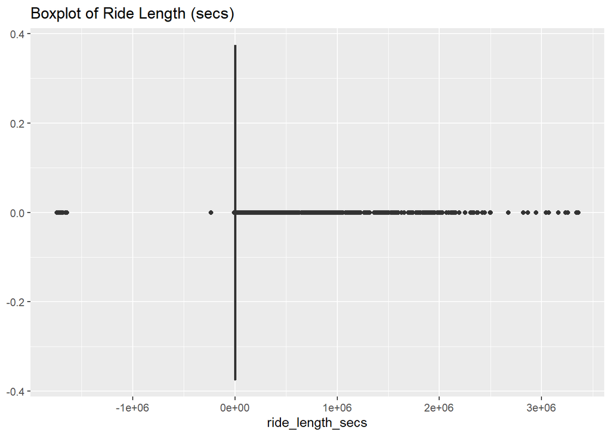

```r
ggplot(data = df) +
  geom_boxplot(mapping = aes(x = ride_length_secs)) +
  labs(title = "Boxplot of Ride Length (secs)")
```

```r
sum(df$ride_length_secs < 0)
```

```
## [1] 5400
```

```r
sum(df$ride_length_secs < 60)
```

```
## [1] 80515
```

**There are 5400 observations with ‘ride_length_secs’ < 0, which we will remove from the dataset.**

Additionally, following the guidelines from the owners of the dataset (see link below), we will also **remove trips that were < 60 secs** (80,515 observations, incl. the 5400 negative values) to account for false starts or users trying to re-dock a bike.

Source: https://www.divvybikes.com/system-data

```r
df <- df[!(df$ride_length_secs < 60),]
summary(df$ride_length_secs)
```

```
##    Min. 1st Qu.  Median    Mean 3rd Qu.    Max.
##      60     445     782    1424    1413 3356649
```

```r
summary(df$ride_length_mins)
```

```
##     Min.  1st Qu.   Median     Mean  3rd Qu.     Max.
##     1.00     7.42    13.03    23.73    23.55 55944.15
```

As the objective of this project is to understand the difference in usage between members and casual riders of Cyclistic, we will keep the outliers and investigate further. If the objective was towards machine learning application, then we should consider treatment of these outliers (1.5xIQR).

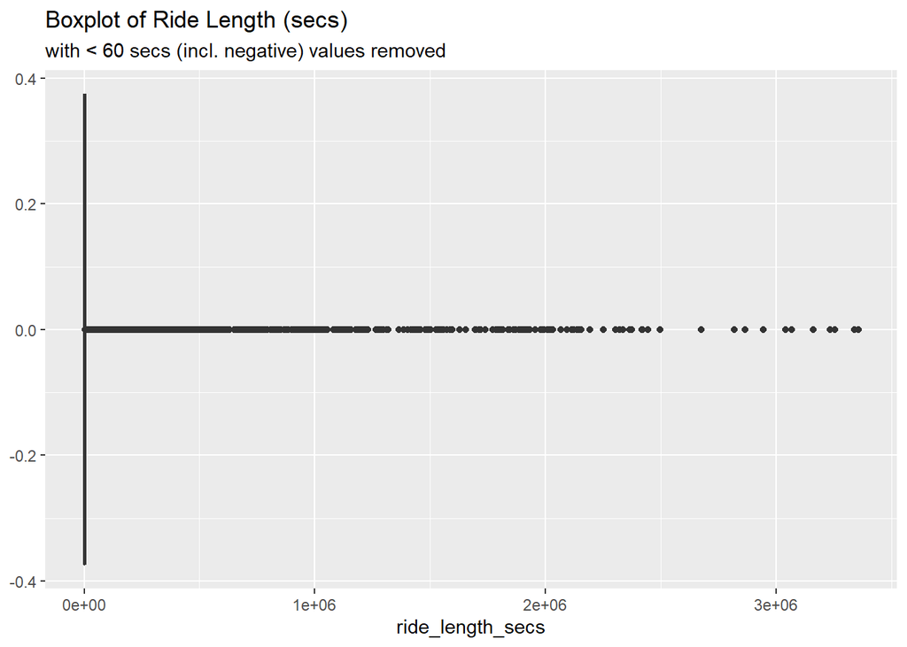

```r
ggplot(data = df) +
  geom_boxplot(mapping = aes(x = ride_length_secs)) +
  labs(title = "Boxplot of Ride Length (secs)",
       subtitle = "with < 60 secs (incl. negative) values removed")
```

As we want to understand the difference between members and casual riders, we group the dataset as such in the code below and print the median ride_length for each group:

*Note: as it is easier to interpret minutes than seconds, we will analyze ride_length in minutes going forward*

```r
df %>%
  group_by(member_casual) %>%
  summarise(median_duration_mins = median(ride_length_mins),
            number_of_rides = n()) %>%
  mutate(percentage =
           round(number_of_rides / sum(number_of_rides) * 100, 2))
```

```
## # A tibble: 2 x 4
##   member_casual median_duration_mins number_of_rides percentage
##   <chr>                        <dbl>           <int>      <dbl>
## 1 casual                        17.4         2192864       45.4
## 2 member                        10.4         2639693       54.6
```

From the table we above, we observe that in the last 12-months:

- 45% of rides are attributed to Casual riders with a median ride_length of 17.42 mins, and
- 55% of rides are attributed to Member riders with a median ride_length of 10.42 mins

*We use median as opposed to mean as the distribution is right skewed, which can been seen in the boxplot earlier*

#### EDA: Ride Length, by rideable_type

We can further group the data by rideable_type to explore if there are preferences among Member and Casual riders towards the type of bicycle they hire:

```r
df %>%
  group_by(member_casual, rideable_type) %>%
  summarise(median_duration_mins = median(ride_length_mins),
            number_of_rides = n(), .groups = "drop_last") %>%
  mutate(
    percentage = round(number_of_rides / sum(number_of_rides) * 100, 2))
```

```
## # A tibble: 6 x 5
## # Groups:   member_casual [2]
##   member_casual rideable_type median_duration_mins number_of_rides percentage
##   <chr>         <chr>                        <dbl>           <int>      <dbl>
## 1 casual        classic_bike                 16.9           915127       41.7
## 2 casual        docked_bike                  24.7           538486       24.6
## 3 casual        electric_bike                14.3           739251       33.7
## 4 member        classic_bike                 10.6          1343305       50.9
## 5 member        docked_bike                  10.9           491021       18.6
## 6 member        electric_bike                 9.83          805367       30.5
```

We can also visualize the above analysis with a jitterplot:

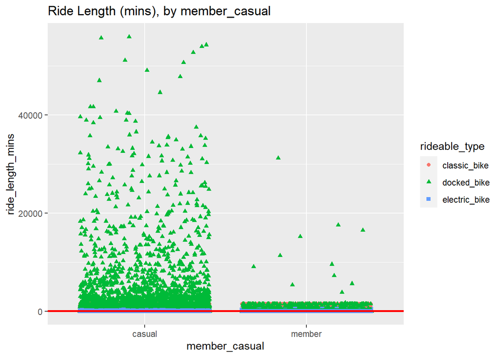

```r
ggplot(data = df) +
  geom_jitter(
    mapping = aes(x = member_casual, y = ride_length_mins,
                  color = rideable_type, shape = rideable_type)) +
  geom_hline(aes(yintercept = 13), col = "red", size = 1) +
  labs(title = "Ride Length (mins), by member_casual")
```

From the above plot, we observe that:

- docked_bikes tend to have the longest ride_length
- electric_bikes tend to have the shortest ride_length
- casual riders tend to have a longer ride_length vs. member riders
- ride_length is centered around (most observations) the median = 13 mins (red line) around the bottom of the bars; there are several long ride_lengths attributed to docked_bikes that skew the distribution upwards

We can better see this if we plot ride_length by rideable_type in the jitterplot below, where we observe significant variability in docked_bikes:

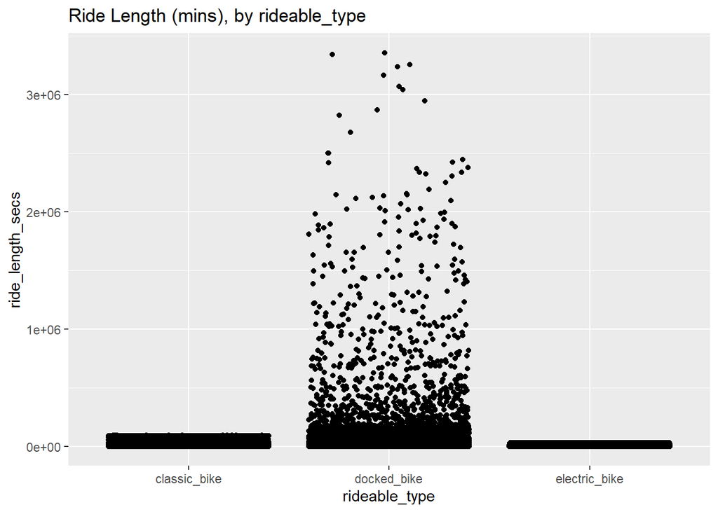

```r
ggplot(data = df) +
  geom_jitter(mapping = aes(x = rideable_type, y = ride_length_secs)) +
  labs(title = "Ride Length (mins), by rideable_type")
```

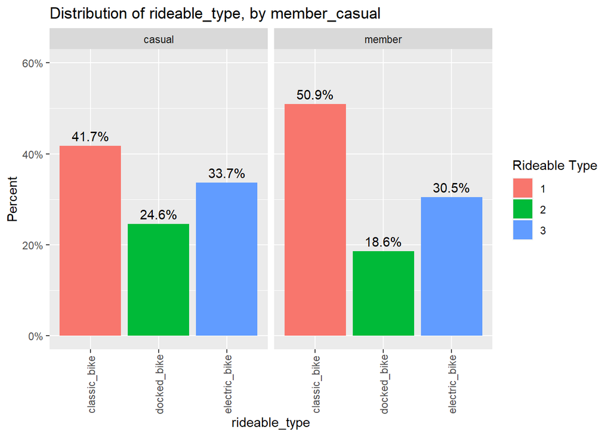

```r
ggplot(data = df, aes(x = rideable_type, group = member_casual)) +
  geom_bar(
    aes(y = ..prop.., fill = factor(..x..)),
    stat = "count") +
  geom_text(
    aes(label = scales::percent(..prop.., accuracy = 0.1), y = ..prop..),
    stat = "count", vjust = -0.5) +
  labs(
    title = "Distribution of rideable_type, by member_casual",
    y = "Percent",
    fill = "Rideable Type") +
  facet_grid(~member_casual) +
  #setting y-limit to avoid cutting-off the label
  scale_y_continuous(labels = scales::percent, limits = c(0, 0.6)) +
  theme(axis.text.x = element_text(angle = 90, vjust = 0.5))
```

As the distribution by rideable_type among Casual and Member riders are quite similar, we might be interested to determine if there is dependence between the type of rider (member, casual) and rideable_type(classic, docked, electric); i.e. is the distribution of one variable affected by the presence of the other.

To determine this, we run a simple chi2 test with a 95% significance level below where:

H0: Type of Rider and rideable_type are independent

H1: Type of Rider and rideable_type are dependent

```r
contingency_table <- table(df$member_casual, df$rideable_type)
chisq.test(contingency_table)
```

```
##
##  Pearson's Chi-squared test
##
## data:  contingency_table
## X-squared = 45269, df = 2, p-value < 2.2e-16
```

Since the p-value < alpha = 0.05, we reject the H0 hypothesis which implies that the type of rider and rideable_type are dependent.

#### EDA: Ride Length, by days_of_week

We will proceed with the EDA to observe any meaningful differences in ride_length between Casual and Member riders by the days of the week.

```r
df_dow <- df %>%
  group_by(member_casual, day_of_week) %>%
  summarise(median_duration_mins = median(ride_length_mins),
            #we "drop_last" to set the base of percentage as member_casual
            number_of_rides = n(), .groups = "drop_last") %>%
  mutate(percentage = paste0(round(number_of_rides / sum(number_of_rides) * 100, 0),"%"))
df_dow
```

```
## # A tibble: 14 x 5
## # Groups:   member_casual [2]
##    member_casual day_of_week median_duration_mins number_of_rides percentage
##    <chr>         <ord>                      <dbl>           <int> <chr>
##  1 casual        Monday                     17.4           246975 11%
##  2 casual        Tuesday                    15.6           238703 11%
##  3 casual        Wednesday                  15.4           238299 11%
##  4 casual        Thursday                   15.0           244320 11%
##  5 casual        Friday                     16.3           317525 14%
##  6 casual        Saturday                   19.4           492285 22%
##  7 casual        Sunday                     20.2           414757 19%
##  8 member        Monday                      9.95          358517 14%
##  9 member        Tuesday                     9.9           393778 15%
## 10 member        Wednesday                  10.0           400270 15%
## 11 member        Thursday                    9.92          384235 15%
## 12 member        Friday                     10.2           389467 15%
## 13 member        Saturday                   11.7           382530 14%
## 14 member        Sunday                     11.7           330896 13%
```

We can also visualize the above information in the plots below:

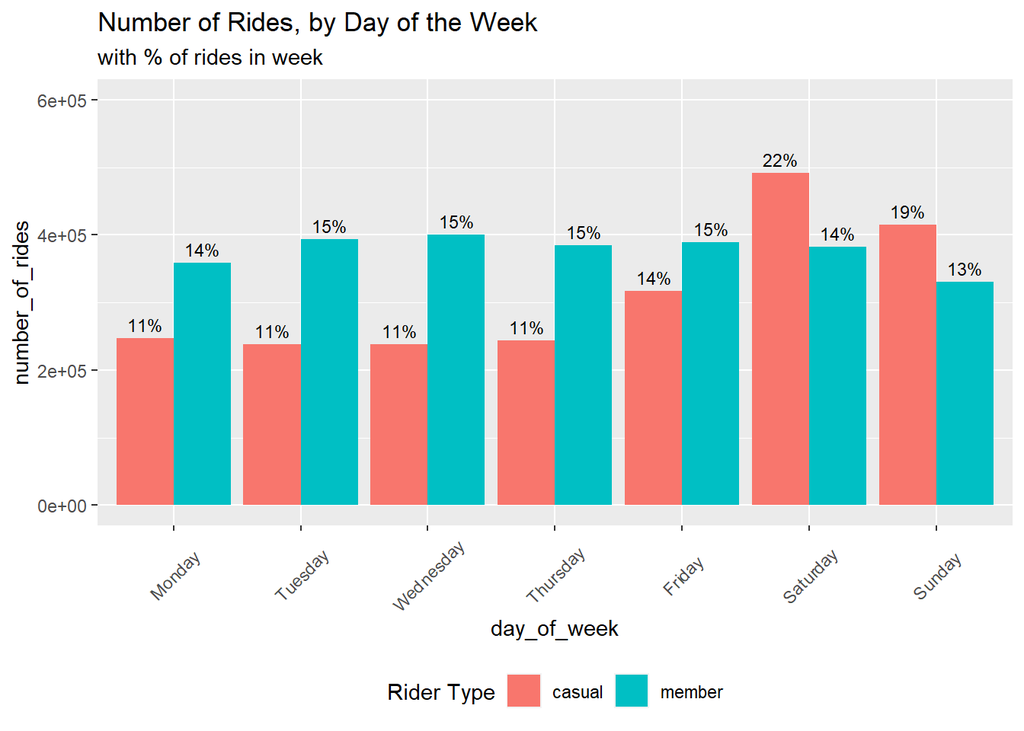

```r
df_dow %>%
  ggplot(aes(x = day_of_week, y = number_of_rides, fill = member_casual)) + geom_col(position = "dodge") +
  geom_text(
    aes(label = percentage),
    position = position_dodge(width = 0.9),
    vjust = -0.5, size = 3) +
  labs(
    title = "Number of Rides, by Day of the Week",
    subtitle = "with % of rides in week",
    fill = "Rider Type") +
  ylim(0, 600000) +
  theme(
    axis.text.x = element_text(angle = 45, vjust = 0.5),
    legend.position = "bottom")
```

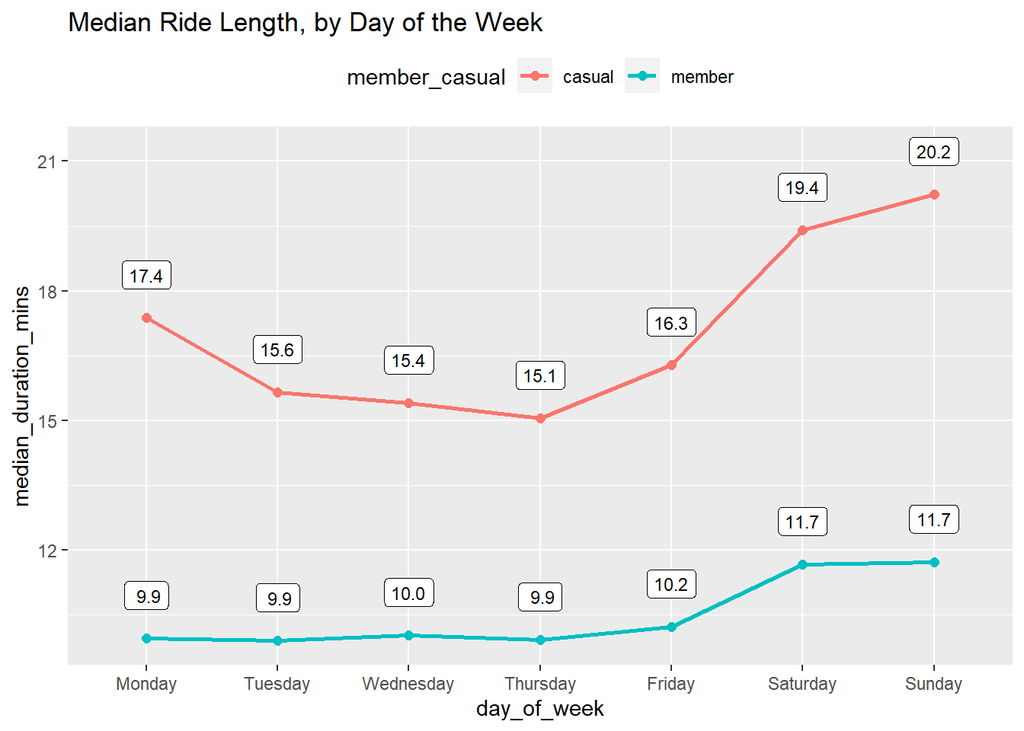

```r
df_dow %>%
  ggplot(aes(x = day_of_week, y = median_duration_mins, group = member_casual)) +
  geom_line(aes(color = member_casual), size = 1) +
  geom_point(aes(color = member_casual), size = 2) +
  geom_label(
    aes(label = sprintf("%4.1f", median_duration_mins)),
    nudge_y = 1, size = 3) +
  labs(title = "Median Ride Length, by Day of the Week") +
  theme(legend.position = "top")
```

From the above plots, we observe that in the last 12-months:

- Ridership for Casual riders tend to be higher towards the end of the week (Fridays, Saturdays and Sundays), while ridership for Member riders are consistent across the week
- Ride lengths for Casual riders are consistently higher than Member riders across the week (also observed from the earlier jitterplot of ride length)
- Ride lengths are higher during the weekend for both Casual (avg. median duration of 19.8 mins vs. weekday 16.0 mins) and Member riders (11.7 mins vs. 10.0 mins)

#### EDA: Ride Length, by day_of_week, by rideable_type

In the code below, we add another layer of grouping to the dataframe: rideable_type

```r
df_dow2 <- df %>%
  group_by(member_casual, rideable_type, day_of_week) %>%
  summarise(median_duration_mins = median(ride_length_mins),
            number_of_rides = n(), .groups = "drop_last") %>%
  mutate(percentage = paste0(round(number_of_rides / sum(number_of_rides) * 100, 0),"%"))
df_dow2
```

```
## # A tibble: 42 x 6
## # Groups:   member_casual, rideable_type [6]
##    member_casual rideable_type day_of_week median_duration_mins number_of_rides
##    <chr>         <chr>         <ord>                      <dbl>           <int>
##  1 casual        classic_bike  Monday                      16.9           99326
##  2 casual        classic_bike  Tuesday                     15.4           95463
##  3 casual        classic_bike  Wednesday                   15             92246
##  4 casual        classic_bike  Thursday                    14.7           97494
##  5 casual        classic_bike  Friday                      15.7          127518
##  6 casual        classic_bike  Saturday                    18.4          217557
##  7 casual        classic_bike  Sunday                      19.2          185523
##  8 casual        docked_bike   Monday                      25.5           59773
##  9 casual        docked_bike   Tuesday                     22.8           51355
## 10 casual        docked_bike   Wednesday                   21.5           55699
## # ... with 32 more rows, and 1 more variable: percentage <chr>
```

Simiarly, we can visualize the above analysis with the charts below:

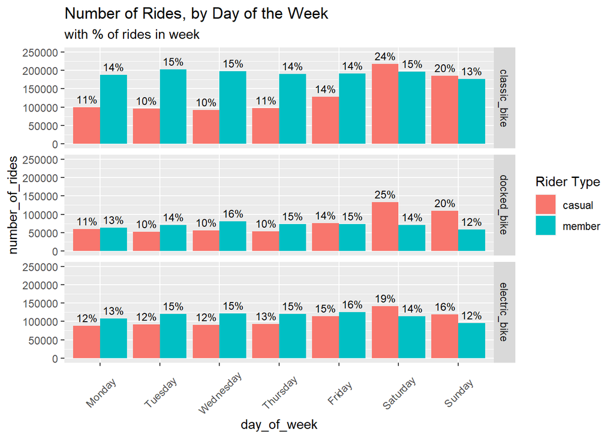

```r
df_dow2 %>%
  ggplot(aes(x = day_of_week, y = number_of_rides, fill = member_casual)) + geom_col(position = "dodge") +
  geom_text(
    aes(label = percentage),
    position = position_dodge(width = 0.9),
    vjust = -0.5, size = 3) +
  facet_grid(rows = vars(rideable_type)) +
  labs(
    title = "Number of Rides, by Day of the Week",
    subtitle = "with % of rides in week",
    fill = "Rider Type") +
  ylim(0, 250000) +
  theme(
    axis.text.x = element_text(angle = 45, vjust = 0.5),
    legend.position = "right")
```

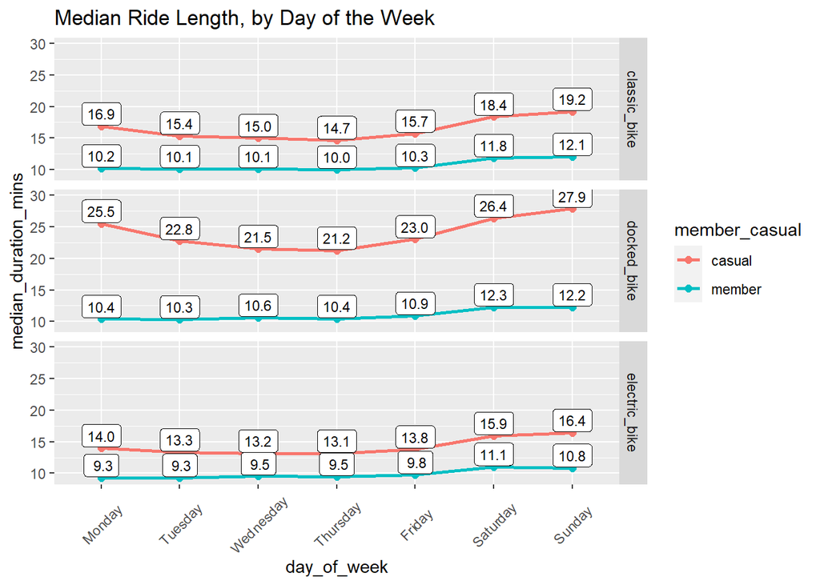

```r
df_dow2 %>%
  ggplot(aes(x = day_of_week, y = median_duration_mins, group = member_casual)) +
  geom_line(aes(color = member_casual), size = 1) +
  geom_point(aes(color = member_casual), size = 2) +
  geom_label(
    aes(label = sprintf("%4.1f", median_duration_mins)),
    nudge_y = 2, size = 3) +
  facet_grid(rows = vars(rideable_type)) +
  labs(title = "Median Ride Length, by Day of the Week") +
  theme(
    axis.text.x = element_text(angle = 45, vjust = 0.5),
    legend.position = "right")
```

From the above plots, we observe that in the last 12-months:

- Ridership for Casual riders tend to be higher during weekend (Saturdays and Sundays) for **classic and docked bikes**, but note less variability for **electric bikes**
- Confirming our earlier analysis, ridership for Member riders is consistent across the week regardless of rideable type

For ride length:

- Ride lengths for Casual riders are consistently higher than Member riders across the week, regardless of rideable type
- Ride lengths are higher during the weekend for both Casual and Member riders, regardless of rideable type
- Ride lengths are the longest for docked bikes, followed by classic then electric bikes

#### EDA: Ride Length, by Station

Next, we will explore the data by station, both start and end, to observe if there are any meaningful differences between Casual and Member riders and where they hire and dock their bikes.

However, as mentioned earlier, it would be ideal if we aggregate the data given that there are >750 unique values. For the purposes of this project, we will leave it non-aggregated and focus on the top 5-10 stations. We will also remove the 3% missing values in start_ and end_station_name.

In the code below, we group the data by start_station_name to identify the most popular station among riders:

```r
df_start <- df %>%
  filter(!is.na(start_station_name)) %>%  #filter out missing values
  group_by(member_casual, start_station_name) %>%
  summarise(median_duration_mins = median(ride_length_mins),
            number_of_rides = n(), .groups = "drop_last") %>%
  mutate(percentage = paste0(round(number_of_rides / sum(number_of_rides) * 100, 2),"%")) %>%
  arrange(member_casual, desc(number_of_rides)) %>%
  slice_max(order_by = number_of_rides, n = 10) #get top 10
df_start #print results
```

```
## # A tibble: 20 x 5
## # Groups:   member_casual [2]
##    member_casual start_station_name  median_duration~ number_of_rides percentage
##    <chr>         <chr>                          <dbl>           <int> <chr>
##  1 casual        Streeter Dr & Gran~            29.0            56175 2.63%
##  2 casual        Millennium Park                32.0            31093 1.46%
##  3 casual        Michigan Ave & Oak~            28.3            27554 1.29%
##  4 casual        Lake Shore Dr & Mo~            31.9            26826 1.26%
##  5 casual        Theater on the Lake            24.0            23369 1.1%
##  6 casual        Shedd Aquarium                 27.2            20817 0.98%
##  7 casual        Lake Shore Dr & No~            22.6            18494 0.87%
##  8 casual        Clark St & Lincoln~            15.7            18435 0.86%
##  9 casual        Indiana Ave & Roos~            25.7            17839 0.84%
## 10 casual        Michigan Ave & Lak~            23.1            17710 0.83%
## 11 member        Clark St & Elm St               9.95           23583 0.92%
## 12 member        Wells St & Concord~             9.95           20996 0.82%
## 13 member        Kingsbury St & Kin~             7.6            20233 0.79%
## 14 member        Wells St & Elm St               8.85           19092 0.75%
## 15 member        Dearborn St & Erie~             8.63           18214 0.71%
## 16 member        Wells St & Hubbard~             8.95           17639 0.69%
## 17 member        Wells St & Huron St             7.5            17636 0.69%
## 18 member        Broadway & Barry A~            10.0            17575 0.69%
## 19 member        St. Clair St & Eri~            12.5            17531 0.68%
## 20 member        Theater on the Lake            19.0            16990 0.66%
```

We can visualize the above with a bar chart below:

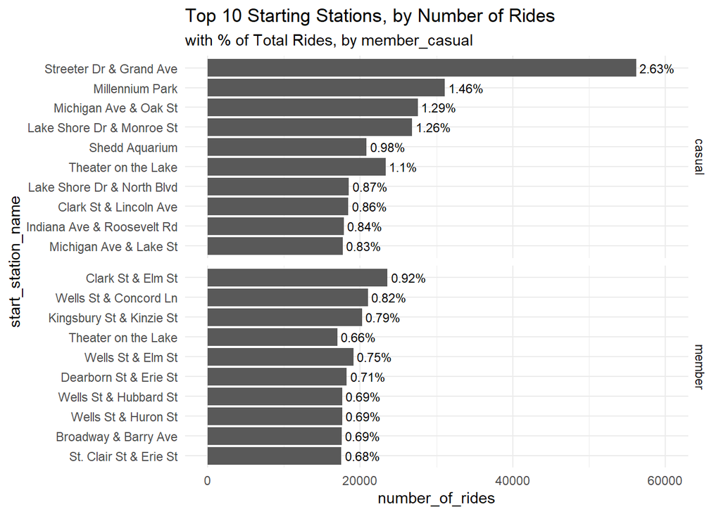

```r
df_start %>%
  ggplot(
    aes(
      x = reorder(start_station_name, number_of_rides),
      y = number_of_rides)) +
  geom_col() +
  geom_text(
    aes(label = percentage),
    hjust = -0.1, size = 3) +
  labs(title = "Top 10 Starting Stations, by Number of Rides",
       subtitle = "with % of Total Rides, by member_casual",
       x = "start_station_name") +
  ylim(0, 60000) +
  facet_grid(rows = vars(member_casual), scales = "free") +
  theme(axis.text.x = element_text(angle = 90, vjust = 0.5)) +
  coord_flip() +
  theme_minimal()
```

We can conduct the same analysis for end_station:

```r
df_end <- df %>%
  filter(!is.na(end_station_name)) %>%  #we filter out missing values
  group_by(member_casual, end_station_name) %>%
  summarise(median_duration_mins = median(ride_length_mins),
            number_of_rides = n(), .groups = "drop_last") %>%
  mutate(percentage = paste0(round(number_of_rides / sum(number_of_rides) * 100, 2),"%")) %>%
  arrange(member_casual, desc(number_of_rides)) %>%
  slice_max(order_by = number_of_rides, n = 10)
df_end
```

```
## # A tibble: 20 x 5
## # Groups:   member_casual [2]
##    member_casual end_station_name    median_duration~ number_of_rides percentage
##    <chr>         <chr>                          <dbl>           <int> <chr>
##  1 casual        Streeter Dr & Gran~            30.6            58387 2.75%
##  2 casual        Millennium Park                29.5            32284 1.52%
##  3 casual        Michigan Ave & Oak~            29.3            28671 1.35%
##  4 casual        Theater on the Lake            28.0            25518 1.2%
##  5 casual        Lake Shore Dr & Mo~            33.2            25366 1.19%
##  6 casual        Lake Shore Dr & No~            24.4            21625 1.02%
##  7 casual        Clark St & Lincoln~            16.6            18947 0.89%
##  8 casual        Shedd Aquarium                 27.5            18518 0.87%
##  9 casual        Michigan Ave & Lak~            23.3            18355 0.86%
## 10 casual        Indiana Ave & Roos~            25.4            18296 0.86%
## 11 member        Clark St & Elm St               9.88           24025 0.94%
## 12 member        Wells St & Concord~             9.62           21576 0.84%
## 13 member        Kingsbury St & Kin~             7.37           20501 0.8%
## 14 member        Wells St & Elm St               8.75           19298 0.76%
## 15 member        Dearborn St & Erie~             8.83           18797 0.74%
## 16 member        St. Clair St & Eri~            11.5            18044 0.71%
## 17 member        Broadway & Barry A~            10.5            17997 0.7%
## 18 member        Wells St & Hubbard~             8.92           17265 0.68%
## 19 member        Wells St & Huron St             7.52           16868 0.66%
## 20 member        Clark St & Lincoln~            11.0            16336 0.64%
```

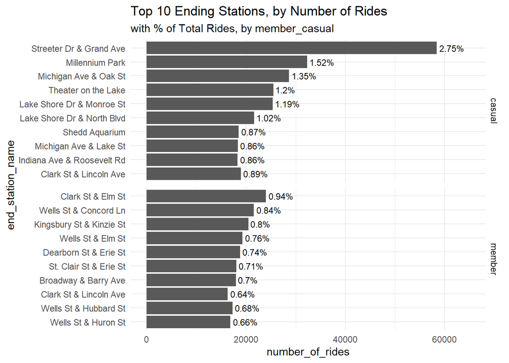

```r
df_end %>%
  ggplot(
    aes(
      x = reorder(end_station_name, number_of_rides),
      y = number_of_rides)) +
  geom_col() +
  geom_text(
    aes(label = percentage),
    hjust = -0.1, size = 3) +
  labs(title = "Top 10 Ending Stations, by Number of Rides",
       subtitle = "with % of Total Rides, by member_casual",
       x = "end_station_name") +
  ylim(0, 65000) +
  facet_grid(rows = vars(member_casual), scales = "free") +
  theme(axis.text.x = element_text(angle = 90, vjust = 0.5)) +
  coord_flip() +
  theme_minimal()
```

To further build upon the analysis, we can try to identify popular routes among riders. In the code below, we create a new column: route, that captures the start_ and end_station_name.

```r
df$route <- paste(df$start_station_name, df$end_station_name, sep = "-")
df_route <- df %>%
  #filter out missing start_ and end_station_name
  filter((!is.na(start_station_name)) & (!is.na(end_station_name))) %>%
  group_by(member_casual, route) %>%
  summarise(median_duration_mins = median(ride_length_mins),
            number_of_rides = n(), .groups = "drop_last") %>%
  mutate(percentage = paste0(round(number_of_rides / sum(number_of_rides) * 100, 2),"%")) %>%
  arrange(desc(number_of_rides)) %>%
  slice_max(order_by = number_of_rides, n = 10)
df_route
```

```
## # A tibble: 20 x 5
## # Groups:   member_casual [2]
##    member_casual route              median_duration_~ number_of_rides percentage
##    <chr>         <chr>                          <dbl>           <int> <chr>
##  1 casual        Streeter Dr & Gra~             40.6            10091 0.48%
##  2 casual        Lake Shore Dr & M~             35.4             6479 0.31%
##  3 casual        Millennium Park-M~             41.9             6044 0.29%
##  4 casual        Michigan Ave & Oa~             46.8             5538 0.27%
##  5 casual        Buckingham Founta~             42.5             3920 0.19%
##  6 casual        Theater on the La~             41.4             3528 0.17%
##  7 casual        Indiana Ave & Roo~             40.9             3492 0.17%
##  8 casual        Lake Shore Dr & M~             22.8             3335 0.16%
##  9 casual        Michigan Ave & 8t~             46.2             2879 0.14%
## 10 casual        Fort Dearborn Dr ~             56.2             2838 0.14%
## 11 member        Ellis Ave & 60th ~              4.48            2077 0.08%
## 12 member        Ellis Ave & 55th ~              4.7             1853 0.07%
## 13 member        MLK Jr Dr & 29th ~              7.35            1388 0.06%
## 14 member        State St & 33rd S~              7.72            1252 0.05%
## 15 member        State St & 33rd S~              3.75            1228 0.05%
## 16 member        Calumet Ave & 33r~              3.45            1149 0.05%
## 17 member        Loomis St & Lexin~              6.84            1090 0.04%
## 18 member        Loomis St & Lexin~              4.88            1061 0.04%
## 19 member        Wells St & Huron ~              4.15            1049 0.04%
## 20 member        Wells St & Elm St~              4.15            1009 0.04%
```

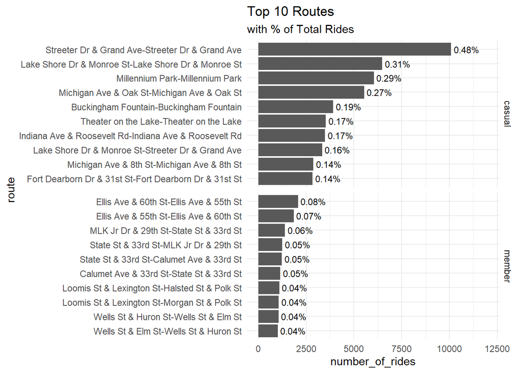

```r
df_route %>%
  ggplot(aes(x = reorder(route, number_of_rides), y = number_of_rides)) +
  geom_col() +
  geom_text(
    aes(label = percentage),
    hjust = -0.1, size = 3) +
  labs(title = "Top 10 Routes",
       subtitle = "with % of Total Rides",
       x = "route") +
  ylim(0, 12000) +
  facet_grid(rows = vars(member_casual), scales = "free") +
  theme(axis.text.x = element_text(angle = 90, vjust = 0.5)) +
  coord_flip() +
  theme_minimal()
```

From the above, we observe that:

- “Streeter Dr & Grand Ave” (return-trip) is the most popular route for Casual riders at 0.48% of total rides by Casual riders in the last 12-months
- Similarly, popular routes for Casual riders are near recreational areas
- “Ellis Ave & 60th St - Ellis Ave & 55th St” is the most popular rote for Member riders at 0.08%, and vice-versa at 0.07% of total rides by Member riders in the last 12-months. Upon further investigation, this area contains many educational facilities (University of Chicago) and healthcare facilities (UCMC)
- The same applies to the 3rd, 4th and 5th most popular route ("MLK Jr Dr & 29th St, State St & 33rd St and Calumet Ave & 33rd St) that is centered by Illinois Institute of Technology

### Key Insights

As a refresher, the 3 analytical objectives we laid out at the beginning are:

1. How do annual members and casual riders use Cyclistic bikes differently?
2. Why would casual riders buy Cyclistic annual memberships?
3. How can Cyclistic use digital media to influence casual riders to become members?

From the Exploratory Data Analysis (EDA) above, we identified the following insights:

#### Rider Type:

- Majority of the rides in the last 12-months are attributed to Members (55%) vs. Casuals (45%)
- Members tend to have a shorter ride length (median = 10.42 mins) vs. Casuals 17.42mins

#### Type of Bike:

- Both Members (51%) and Casuals (42%) have a preference for classic_bikes, followed by electric_bikes (31%, 34% respectively) and finally docked_bikes (18%, 24% respectively), and the distribution of rider type and rideable_type are dependent (as confirmed by a chi2 test with 95% significance value)

#### Day of Week:

- Ridership for Members are consistent across the week, while ridership is higher for Casuals during the weekends
- Ride lengths are longer during the weekends for both Members (avg. median of 11.7 mins vs. weekdays 10.0 mins) and Casuals (19.8 mins vs. 16.0 mins), regardless of rideable_type

#### Popular Stations & Routes:

[figure not shown]

Source: Google Maps

### Recommendation(s)

Based on the above, my recommendation(s) are as follows:

1. **Focus marketing efforts on college students in the area:** consider offering a “student discount” or a flexible pricing plan for students given that the current annual membership requires USD 108 upfront (USD 9/month vs. Single Ride USD 3.30/trip and Day Pass USD 15/day) - allowing a monthly payment scheme might be more palatable for students
2. **Shorten the lock-in for membership:** my assumption is that many riders are turned-off by the upfront USD 108 payment for a one-year membership (the company can confirm this by running a survey with its users). The company can trial a shorter membership period (3-months/6-months) and we can conduct an A/B testing for the promotion efforts to guage the efficacy
3. **Send riders a summary of their activities at the end of every month:** the bar to sign-up for a membership is not very high - at USD 3.30/trip vs. USD 9/month, a Casual rider only needs to take 3 rides in a month for it to make economic sense. A monthly summary might prompt frequent Casual riders to consider a subscription if they are able to visualize how much they could have saved in that month
4. **Shorten the duration on the Day Pass:** there is some buffer on the current 30 mins available with the Day Pass (USD 0.15/min thereafter) - median ride length for Casuals is 17.42 mins and for Members is 10.42 mins. Reducing the cap to 25 mins should not have a significant negative impact, although it depends on how riders view the move. This will motivate Casuals to consider a membership to avoid “overcharges” and the stress of monitoring their ride time

Source for pricing: https://www.divvybikes.com/